# Final Project

# Introduction

Understanding what drives customers to buy organic products is key as in many segments the market growth of organic products is outstripping that of the overall segment. Organic products also represent billions of dollars in sales and the availability of orgnic products is a key factor in why some consumers pick one grocery store over another.

A recent report from the Organic Trade Association stated that the U.S. market for organic products was $52.2 billion and accounted for 5.7% of all food sales in the United States in 2018. They reported that the majority of organic food sales were fruits and vegetables, accounting for $17.4 billion in sales; dairy and eggs made up the second-largest organic food category at $6.5 billion in sales. Sales of organic fruits and vegetables grew by 5.6% which far surpassed the growth of the overall fruit and vegetable market at 1.7%. Non-food organic products saw 10.6% overall growth from 2017 to 2018 also surpassing the growth of the overall non-food segment at 3.6% (Redman). And recent polling by IRI, a consumer research company, found that 49% of Millennials and 40% of Gen X shoppers consider having a good selection of natural and organic foods important in selecting a grocery store (Emarketer).

For this project, we are acting as a team of analysts who are interested in identifying households that are likely to buy organic products so we know who to target for an organic product marketing campaign. In order to do this, we will use data at both the household and basket level and try classification models to accurately identify these households. We are also interested in organic trends over time and will use a classification model to attempt to flag households who have increased their spending on organic products in year two. Finally, we will use market basket analysis to mine for association rules to give insight on organic products frequently bought together.

## The Data

The data set we are using for our project is called “The Complete Journey 2.0” and it is found on the 84.51 website (84.51). This data set has transactions at the household level from a group of 5,000 households over a two year period. This is a relational data set comprised of household data, transaction data, and product data that can be combined by household and product IDs. The household data set has demographic information such as the size, income, and age of the household.The transaction data set is made up of over 10 billion rows; each row represents one item purchased by a customer and provides an ID for the item purchased, the household who purchased it, a ‘Basket’ ID which groups items purchased in the same transation, and information like the the date purchased and cost of the item. The product data set links to the transaction data set by the product ID and gives some high level information on each product including the product category, whether a product is organic, and whether the product is a private or national brand.

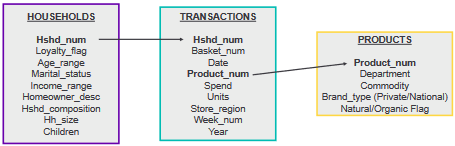

## Major Findings

Through some preliminary data exploration, we see that both organic and non-organic households appear to be somewhat normally distributed by age ranges. There doesn’t appear to be a clear demographic factor that organic households share, so this is something we will try to narrow down in our future analysis.

## Market Basket Analysis

In order to mine the transaction data for insights into what kinds of organic products our customers purchase together, we performed market basket analysis using the Apriori algorithm.

```r
itemFrequencyPlot(baskets, support = 0.1, cex.names = 0.6)
```

[output not shown]

```r
basket_rules <- apriori(baskets, parameter = list(sup = 0.01, conf = 0.8, target = "rules", maxlen = 3))
```

```r
summary(basket_rules)
```

[output not shown]

```r
organic_names <- colnames(select(organic_market_basket, starts_with("ORGANIC")))
organic_lhs <- subset(basket_rules, subset = lhs %in% organic_names & lift > 1.2)

inspect(organic_lhs)
```

[output not shown]

```r
organic_only <- market_basket %>%
  filter_at(vars(starts_with("ORGANIC")), any_vars(. == 1)) %>%
  select(starts_with("ORGANIC"))

organic_baskets <- as(as.matrix(organic_only[, -1]), "transactions")
itemFrequencyPlot(organic_baskets, support = 0.01, cex.names = 0.7)
```

[output not shown]

```r
organic_basket_rules <- apriori(organic_baskets, parameter = list(sup = 0.001, conf = 0.6, target = "rules", maxlen = 5))
summary(organic_basket_rules)
```

[output not shown]

```r
inspect(subset(organic_basket_rules, subset = lift > 2.8))
```

[output not shown]

# Works Cited

84.51. “The Complete Journey 2.0” Area 51 Source Files. https://www.8451.com/area51

Redman, Russell. “Organic Products Hit a Record-Breaking High.” Supermarket News (May 20, 2019). https://search-proquest-com.proxy.libraries.uc.edu/docview/2238503079?accountid=2909.)

Emarketer. “Consumer Connect Q4 2019: Channel Trends in CPG Today.” https://chart-na1.emarketer.com/234160/attributes-us-internet-users-find-important-store-selection-process-by-generation-dec-2019-of-respondents-each-group